# Anime Streaming Content Strategy

### An Analytical Deep Dive into Anime Audience Trends

**Author:** Shohag  
**Tools:** Python (Pandas, Matplotlib, Seaborn)  
**Dataset:** MyAnimeList (Kaggle)

## Project Overview

Anime streaming platforms face increasing competition and rising licensing costs.  
Choosing the right content requires understanding how audience behavior has evolved and which anime characteristics drive popularity in the streaming era.

This project analyzes anime performance data to uncover:

- How the anime market has changed over time
- Whether newer and shorter anime perform differently
- Which titles represent undervalued licensing opportunities (“hidden gems”)

The goal is to translate data into **actionable content strategy insights**, not just statistics.

## Imports & Environment Setup

## Data Loading

|  | anime_id | title | score | rank | popularity | members | synopsis | start_date | end_date | type | episodes | image_url |
| --- | --- | --- | --- | --- | --- | --- | --- | --- | --- | --- | --- | --- |
| 0 | 28977 | Gintama° | 9.05 | 8 | 347 | 680037 | Gintoki, Shinpachi, and Kagura return as the f... | 2015-01-01 | 2016-01-01 | TV | 51.0 | https://cdn.myanimelist.net/images/anime/3/720... |
| 1 | 57555 | Chainsaw Man Movie: Reze-hen | 9.18 | 2 | 962 | 282129 | Sequel to Chainsaw Man . | 2025-01-01 | 2025-01-01 | Movie | 1.0 | https://cdn.myanimelist.net/images/anime/1763/... |
| 2 | 11061 | Hunter x Hunter (2011) | 9.03 | 9 | 8 | 3107455 | Hunters devote themselves to accomplishing haz... | 2011-01-01 | 2014-01-01 | TV | 148.0 | https://cdn.myanimelist.net/images/anime/1337/... |
| 3 | 52991 | Sousou no Frieren | 9.29 | 1 | 121 | 1269074 | During their decade-long quest to defeat the D... | 2023-01-01 | 2024-01-01 | TV | 28.0 | https://cdn.myanimelist.net/images/anime/1015/... |
| 4 | 9969 | Gintama' | 9.02 | 11 | 406 | 601940 | After a one-year hiatus, Shinpachi Shimura ret... | 2011-01-01 | 2012-01-01 | TV | 51.0 | https://cdn.myanimelist.net/images/anime/4/503... |

The dataset contains information on anime titles, including audience ratings, popularity, episode counts, and release dates.

## Data Overview

```
(10000, 12)
```

```
<class 'pandas.DataFrame'>
RangeIndex: 10000 entries, 0 to 9999
Data columns (total 12 columns):
 #   Column      Non-Null Count  Dtype
---  ------      --------------  -----
 0   anime_id    10000 non-null  int64
 1   title       10000 non-null  str
 2   score       10000 non-null  float64
 3   rank        10000 non-null  int64
 4   popularity  10000 non-null  int64
 5   members     10000 non-null  int64
 6   synopsis    9998 non-null   str
 7   start_date  9998 non-null   str
 8   end_date    9916 non-null   str
 9   type        10000 non-null  str
 10  episodes    9952 non-null   float64
 11  image_url   10000 non-null  str
dtypes: float64(2), int64(4), str(6)
memory usage: 937.6 KB
```

The dataset is largely clean, with minor missing values in date and episode fields that are handled during preprocessing.

## Data Preparation

```
anime_id               int64
title                    str
score                float64
rank                   int64
popularity             int64
members                int64
synopsis                 str
start_date    datetime64[us]
end_date      datetime64[us]
type                     str
episodes               int64
image_url                str
start_year             Int64
dtype: object
```

Date fields were converted to datetime format, and episode counts were standardized to integer values.  
The original dataset required minimal cleaning.

## Market Expansion: Pre vs Post 2010

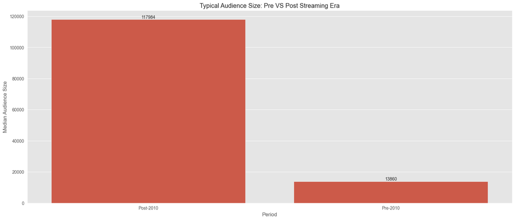

Average audience size also increased substantially over this period, signaling not only broader viewer adoption but also the emergence of blockbuster titles capable of reaching massive scale.

## Format Shift: Short vs Long Anime

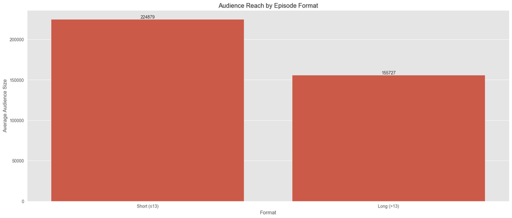

Short-format anime demonstrate a clear audience advantage over longer series, achieving higher average audience size while maintaining comparable viewer ratings. This pattern suggests that lower viewing commitment may enhance discoverability and completion rates — factors that are especially important for engagement-driven streaming platforms.

## Hidden Gems: High Quality, Low Exposure Anime

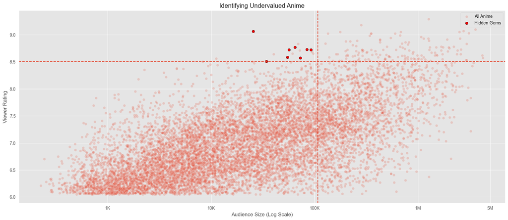

This analysis highlights a small group of high-rating anime that have not yet achieved broad audience reach.  
These titles represent potential undervalued licensing opportunities, offering strong viewer satisfaction with lower acquisition risk.

## Audience Growth Over Time: Tracking the Rise of Anime Popularity

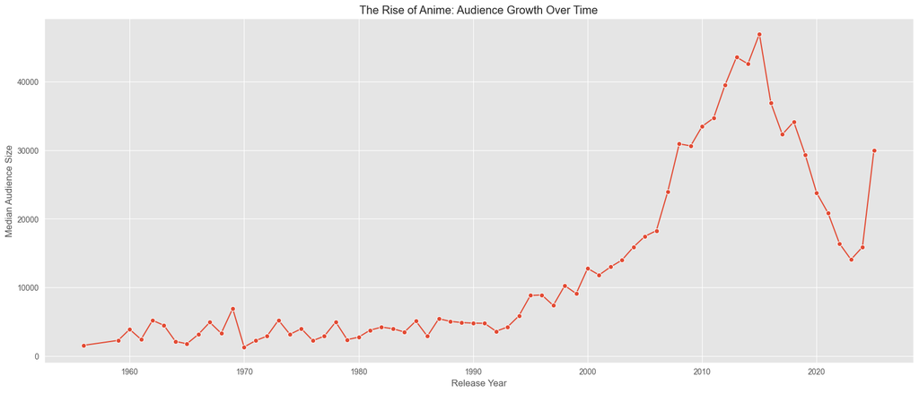

## The Episode Sweet Spot: Identifying the Format That Maximizes Audience Reach

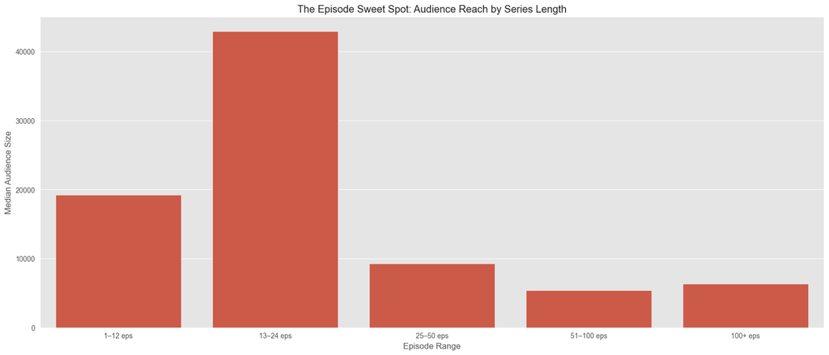

Anime series with 13–24 episodes achieve the highest typical audience reach, significantly outperforming both shorter and longer formats. This suggests that this range balances narrative depth with manageable viewing commitment, making it particularly well-suited to modern streaming behavior. Extremely long series, while occasionally successful, tend to attract smaller typical audiences — likely due to the higher time investment required from viewers.

## Quality vs Reach: Do Higher Ratings Translate Into Larger Audiences?

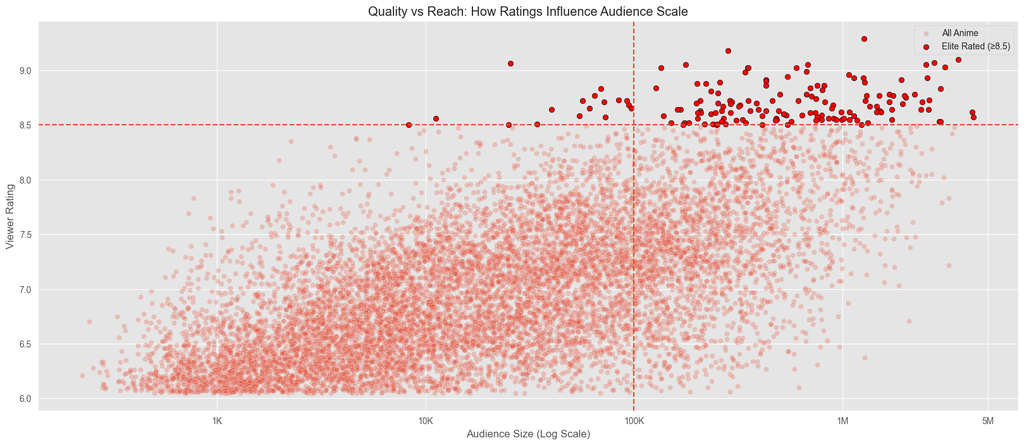

Higher-rated anime consistently attract substantially larger audiences, with elite titles (rating ≥ 8.5) demonstrating dramatically higher median and average audience sizes than lower-rated counterparts. This relationship suggests that strong viewer satisfaction is closely linked to discoverability and word-of-mouth growth.

However, the presence of moderately rated yet widely viewed titles indicates that factors such as franchise strength, brand recognition, and marketing also influence audience scale. Licensing strategies should therefore prioritize quality while remaining attentive to broader commercial signals.

## Strategic Recommendations

Based on the analysis, several strategic implications emerge for streaming platforms seeking to optimize content acquisition:

Target the 13–24 episode range when possible.  
This format consistently delivers the strongest typical reach, suggesting strong alignment with modern consumption habits.

Use viewer ratings as a risk-reduction signal.  
Elite-rated anime overwhelmingly attract larger audiences, making high ratings a reliable indicator of licensing potential.

Identify undervalued high-quality titles early.  
Hidden gems present opportunities to secure strong content before broader market discovery drives up acquisition costs.

Avoid overcommitting to extremely long series unless supported by established franchise power.  
While exceptions exist, the typical performance of very long formats is less predictable and may introduce engagement risk.

## Conclusion

Format plays a critical role in performance: mid-length series strike the strongest balance between depth and accessibility, while extremely long titles face higher engagement barriers. Additionally, the strong relationship between ratings and audience size suggests that viewer satisfaction remains a powerful driver of discovery.

While historical analysis cannot guarantee future performance, the consistency of these patterns provides a strong foundation for data-informed licensing decisions.